# GeoGame Survey Results

Christina Maimone

2017-05-03

# Summary

People who played the GeoGame more thought they were learning and reported increased interest in world affairs compared to those who played less frequently.

But whether they got the geography test questions correct (a proxy for actual learning) is more of a function of their base level of geographic knowledge than how much they played the GeoGame or whether they had seen the specific questions during the GeoGame. The exception to this was for two of the harder/less familiar GeoGame questions about Sri Lanka and the largest country in the Southern Hemisphere; for those questions, having seen the question during the GeoGame did lead to a higher probability of getting the question correct during the survey.

Some GeoGame players may be learning a few geography facts, particularly when exposed to questions about new countries and concepts, but there’s little evidence of overall broad geographic learning in this imperfect test/dataset. Part of this is likely due to people with greater base geography knowledge and interest playing the game more than those who are less knowledgeable/interested; such people have fewer opportunities to learn from the game.

# Note

Some additional model specifications and checks were run in addition to what’s presented here. Because they didn’t lead anywhere productive, they’ve been excluded to make the results easier to follow.

# The Basics

359 completed the survey, and 409 took the survey at all. This is out of 1235 who played GeoGame in the fall or winter who were invited to take the survey.

As a reminder, the questions were:

- What is your primary department/program/major?
- Playing the GeoGame increased my knowledge of where countries are in the world…
- Compared to your peers at Northwestern, do you think your geography knowledge before playing the GeoGame was…
- Playing the GeoGame increased my interest in learning about the world…
- How often did you look up the answer to the daily question on the Internet before submitting?
- Jakarta is in what country?
- What is the largest country by area in the Southern Hemisphere?
- Lagos is in what country?
- Name a country that borders the Black Sea.
- Where is Sri Lanka?
- Where is Turkey?
- Where is Venezuela?
- Where is Egypt?

## Who took the survey?

People who played the GeoGame more often were more likely to take the survey (mean and median for survey respondents is higher than for all players):

Distribution of Number of Days GeoGame Played

|  | Min. | 1st Qu. | Median | Mean | 3rd Qu. | Max. |
| --- | --- | --- | --- | --- | --- | --- |
| Everyone: Fall | 0 | 0 | 1 | 6.532 | 5 | 53 |
| Survey Respondents: Fall | 0 | 0 | 2 | 10.990 | 28 | 53 |
| Everyone: Winter | 0 | 0 | 1 | 6.990 | 6 | 66 |
| Survey Respondents: Winter | 0 | 1 | 5 | 14.270 | 30 | 66 |

But the distribution of faculty, staff, and student matches the GeoGame playing population pretty well:

Distribution of Faculty, Staff, and Students

|  | faculty | grad student | staff | undergrad |
| --- | --- | --- | --- | --- |
| All GeoGame Players | 0.04 | 0.24 | 0.19 | 0.52 |
| Survey Respondents | 0.03 | 0.17 | 0.26 | 0.54 |

The people who took the survey think that their knowledge of geography was generally better than their peers at Northwestern even before playing the GeoGame:

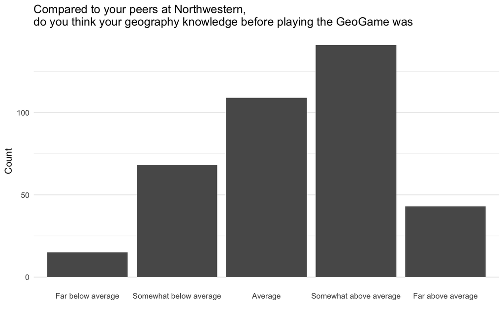

## How are they playing the game?

People aren’t always looking up the answer

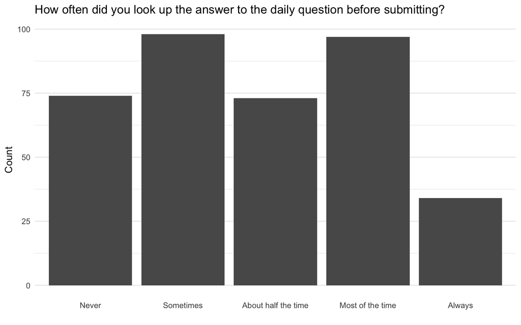

But lookup frequency correlates with self-reported geography knowledge, which makes sense.

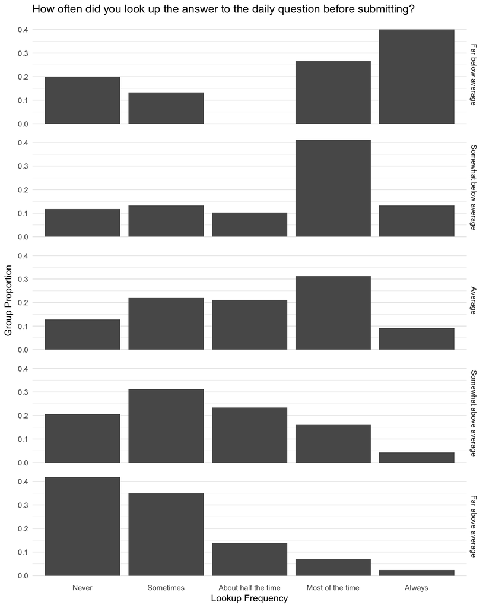

## Big Picture Questions: Self-Reported Interest & Learning

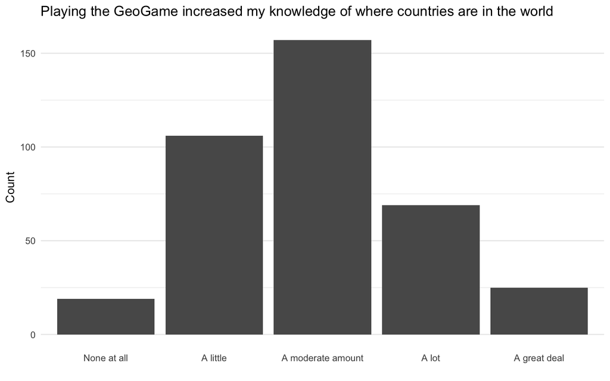

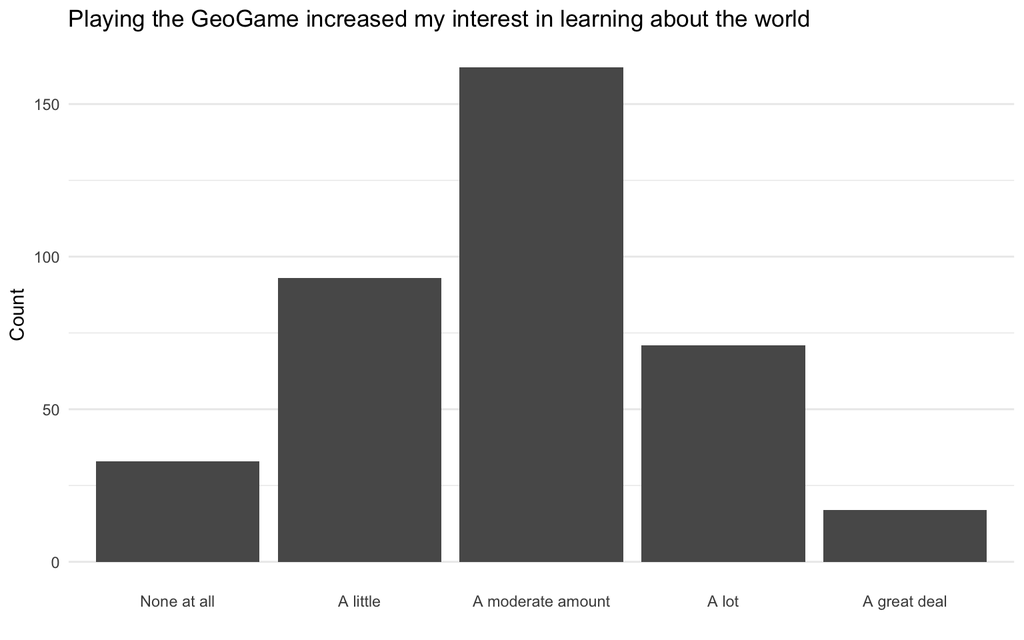

## How did the GeoGame Affect Self-Reported Learning & Interest?

Plots from above, broken down by total number of plays over both quarters <10 or 10+ (based on 2 weeks of play total, and having looked at what breakpoint makes sense in the data):

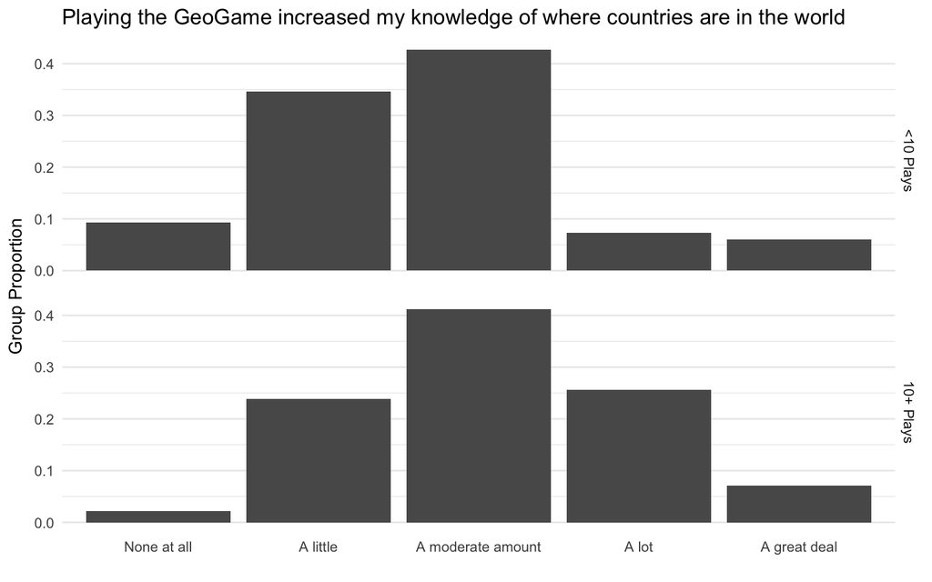

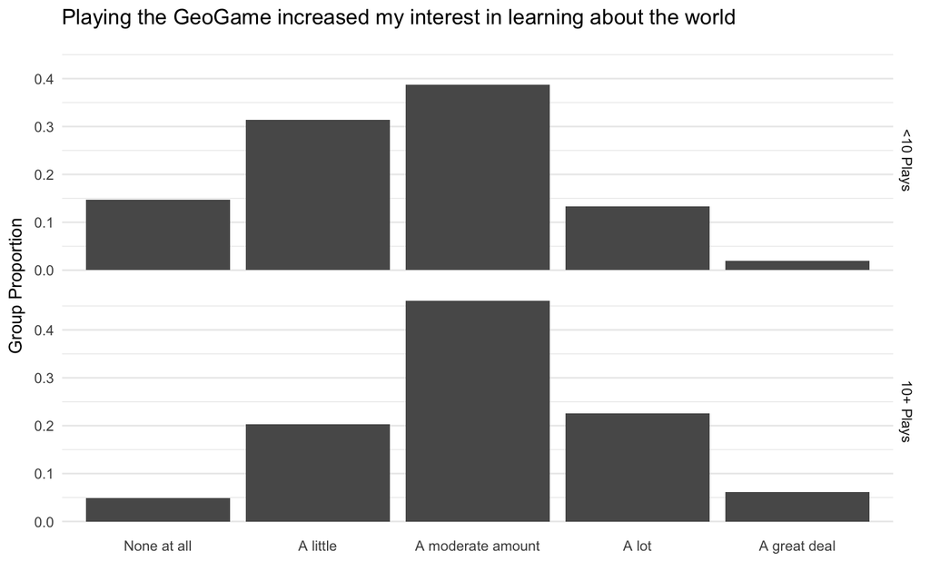

Based on the above, people who played the GeoGame more than 10 times were more likely to say it increased their knowledge and interest “a lot” or “a great deal” than those who played less than 10 times.

Another way to look at this is to examine the distribution of how many times the people giving each answer played:

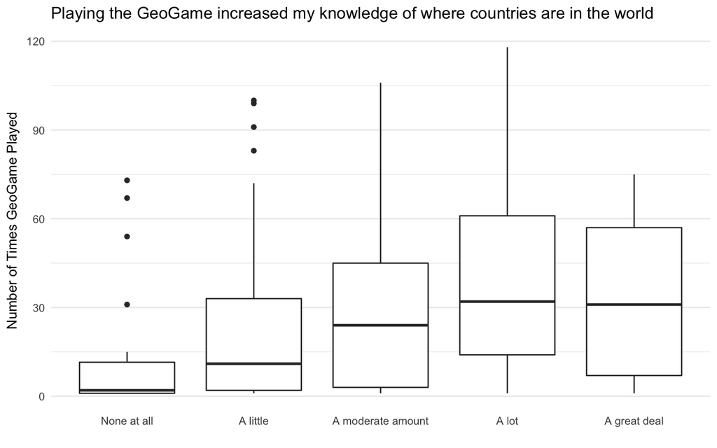

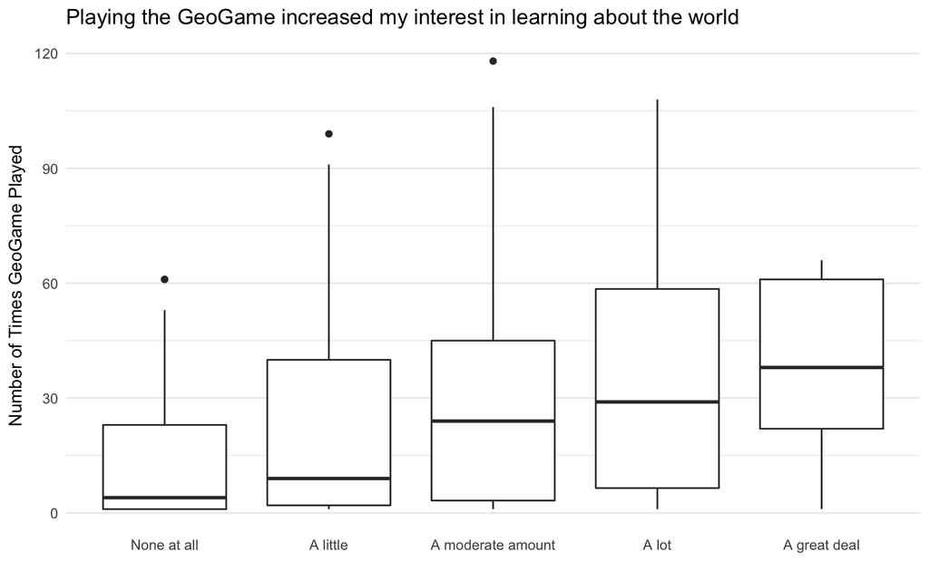

People who didn’t learn or increase interest played on average less than those who did learn or had their interest increased.

And finally a statistical test to show this. We’ll look at the probability that a person answered “a lot” or “a great deal” to the questions. First, total times played, based on `learning` == 1 if “a lot” or “a great deal”:

```
##
##  Welch Two Sample t-test
##
## data:  totalplay[learning == 1] and totalplay[learning == 0]
## t = 4.5298, df = 143.05, p-value = 1.235e-05
## alternative hypothesis: true difference in means is not equal to 0
## 95 percent confidence interval:
##   7.765108 19.789097
## sample estimates:
## mean of x mean of y
##  35.87234  22.09524
```

Then, total times played, based on `interest` == 1 if “a lot” or “a great deal”:

```
##
##  Welch Two Sample t-test
##
## data:  totalplay[interest == 1] and totalplay[interest == 0]
## t = 3.1824, df = 134.87, p-value = 0.001813
## alternative hypothesis: true difference in means is not equal to 0
## 95 percent confidence interval:
##   3.704989 15.869848
## sample estimates:
## mean of x mean of y
##  32.94318  23.15576
```

Both tests show that those who answered “A lot” or “A great deal” did play more than those who didn’t.

# Knowledge Questions

The results in this section only include people who completed the survey. DK includes variations on Don’t Know or blank.

Geography Knowledge Questions (%)

|  | DK | Wrong | Correct |
| --- | --- | --- | --- |
| Jakarta is in what country? | 0.16 | 0.20 | 0.65 |
| What is the largest country by area in the Southern Hemisphere? | 0.03 | 0.50 | 0.48 |
| Lagos is in what country? | 0.25 | 0.30 | 0.45 |
| Name a country that borders the Black Sea. | 0.10 | 0.30 | 0.60 |
| Where is Sri Lanka? | 0.04 | 0.23 | 0.73 |
| Where is Turkey? | 0.02 | 0.23 | 0.75 |
| Where is Venezuela? | 0.03 | 0.42 | 0.56 |
| Where is Egypt? | 0.02 | 0.10 | 0.88 |

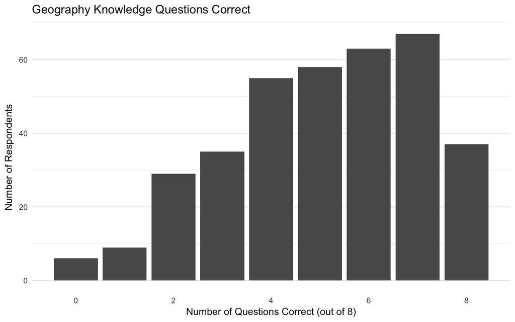

## Accurate Self-reported Knowledge?

Does people’s self-assessment of their knowledge correspond to the number of questions they got right? This isn’t the best comparison because we asked for their knowledge before playing GeoGame and then we quizzed them after, but let’s see if there’s any relation.

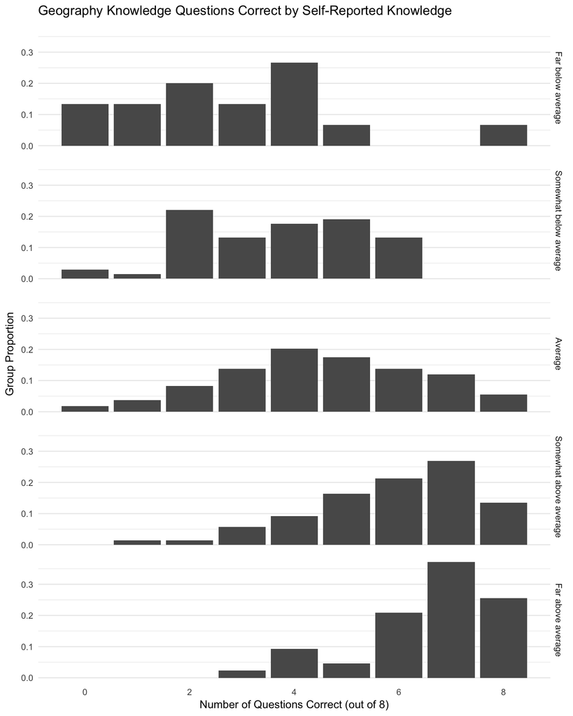

It does look like people are pretty good at identifying their level of geographic knowledge.

| Self-Reported Knowledge | Average Questions Correct |
| --- | --- |
| Far below average | 2.866667 |
| Somewhat below average | 3.688525 |
| Average | 4.561905 |
| Somewhat above average | 5.888889 |
| Far above average | 6.581395 |

## GeoGame Impact on Knowledge

Did people who played GeoGame more get more questions correct? Sort of – the effect is in the middle of the range with people who played more being less likely to get only 2 or 3 correct and more likely to get 4 or 5 correct:

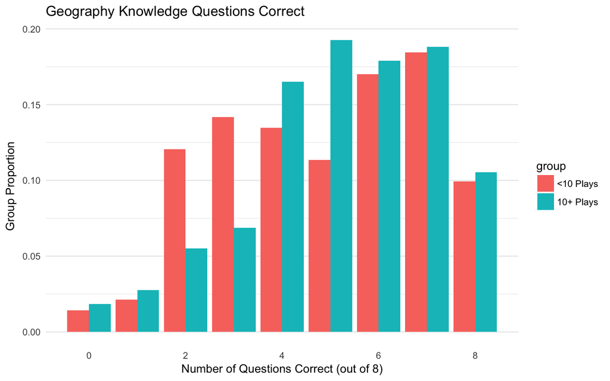

But people who played GeoGame more already think that they have more geographic knowledge than those who played less:

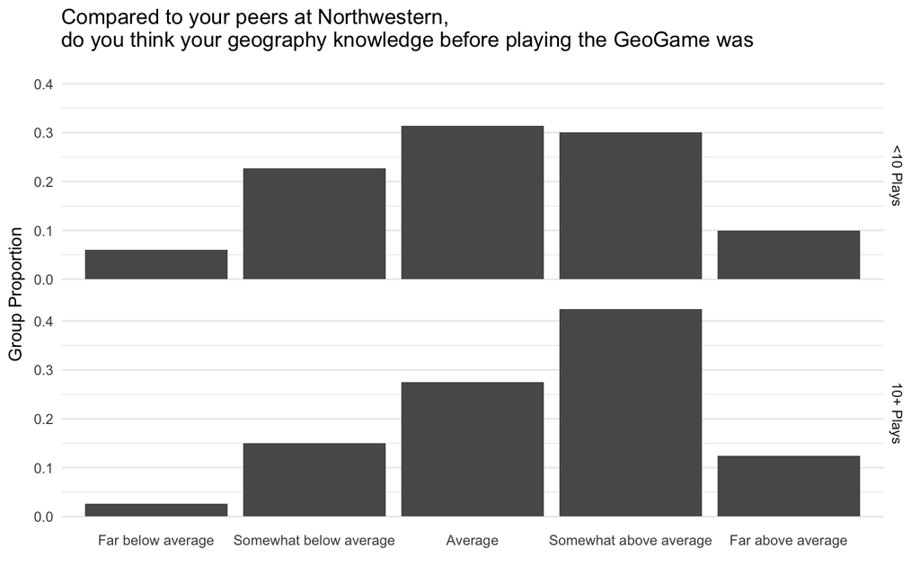

So we’ll look at whether a person having seen a question when playing the GeoGame increased the likelihood that they would get it correct, controlling for the total number of times that they played the GeoGame. Let’s do this by question. The questions that were in the GeoGame in the Fall or Winter were:

- Jakarta is in what country? (10/16/16)
- Which country is the largest by area in the Southern Hemisphere? (1/16/17)
- Lagos is in what country? (10/19/16)
- Where is Sri Lanka? (10/12/16)
- Where is Turkey? (11/14/16)
- Cairo is in what country? (Egypt, 1/30/17)

The two that weren’t were:

- Name a country that borders the Black Sea
- Where is Venezuela?

How many people saw each question?

|  | % not seen | % seen |
| --- | --- | --- |
| Jakarta | 0.84 | 0.16 |
| Largest Southern Hemisphere | 0.82 | 0.18 |
| Lagos | 0.72 | 0.28 |
| Sri Lanka | 0.77 | 0.23 |
| Turkey | 0.72 | 0.28 |
| Egypt (Cairo) | 0.70 | 0.30 |

Then run a logit regression, with the dependent variable being whether they got the question right, and the independent variables being the total number of times they played the GeoGame (in either quarter) and whether they played the GeoGame on the day the Jakarta question was asked:

|  | Jakarta is in what country? |
| --- | --- |
| GeoGame Plays | 0.004 |
|  | (0.005) |
| Question Seen | -0.000 |
|  | (0.333) |
| Constant | 0.497*** |
|  | (0.160) |
| Observations | 359 |
| Log Likelihood | -232.853 |
| Akaike Inf. Crit. | 471.705 |
| *Notes:* | ***Significant at the 1 percent level. |
|  | **Significant at the 5 percent level. |
|  | *Significant at the 10 percent level. |

No statistically significant effect of either variable. Let’s also control for whether the person thinks they know more geography than others. The baseline category is “Average” for “Compared to your peers at Northwestern, do you think your geography knowledge before playing the GeoGame was”

|  | Jakarta is in what country? |
| --- | --- |
| GeoGame Plays | -0.001 |
|  | (0.005) |
| Question Seen | -0.177 |
|  | (0.356) |
| Knowledge: Far below average | -0.691 |
|  | (0.566) |
| Knowledge: Somewhat below average | -0.698** |
|  | (0.329) |
| Knowledge: Somewhat above average | 1.059*** |
|  | (0.291) |
| Knowledge: Far above average | 1.599*** |
|  | (0.486) |
| Constant | 0.300 |
|  | (0.228) |
| Observations | 359 |
| Log Likelihood | -210.366 |
| Akaike Inf. Crit. | 434.732 |
| *Notes:* | ***Significant at the 1 percent level. |
|  | **Significant at the 5 percent level. |
|  | *Significant at the 10 percent level. |

Total number of times played and having seen the question still don’t matter, but those who thought they had above average knowledge were more likely than those who only had average knowledge to get the question right.

### Look at Other Questions

Repeat this model for the other questions:

**Text Answer Questions**

|  | Jakarta | Largest So. Hemi | Lagos |
| --- | --- | --- | --- |
| GeoGame Plays | -0.001 | -0.010** | -0.002 |
|  | (0.005) | (0.005) | (0.005) |
| Question Seen | -0.177 | 0.695** | 0.398 |
|  | (0.356) | (0.340) | (0.292) |
| Knowledge: Far below average | -0.691 | -0.676 | -1.414* |
|  | (0.566) | (0.585) | (0.787) |
| Knowledge: Somewhat below average | -0.698** | -0.078 | -0.857** |
|  | (0.329) | (0.326) | (0.373) |
| Knowledge: Somewhat above average | 1.059*** | -0.156 | 0.542** |
|  | (0.291) | (0.265) | (0.267) |
| Knowledge: Far above average | 1.599*** | 0.150 | 1.643*** |
|  | (0.486) | (0.368) | (0.418) |
| Constant | 0.300 | 0.137 | -0.489** |
|  | (0.228) | (0.222) | (0.228) |
| Observations | 359 | 359 | 359 |
| Log Likelihood | -210.366 | -244.592 | -223.722 |
| Akaike Inf. Crit. | 434.732 | 503.184 | 461.443 |
| *Notes:* | ***Significant at the 1 percent level. |  |  |
|  | **Significant at the 5 percent level. |  |  |
|  | *Significant at the 10 percent level. |  |  |

**Map Questions**

|  | Sri Lanka | Turkey | Egypt |
| --- | --- | --- | --- |
| GeoGame Plays | -0.004 | 0.008 | -0.002 |
|  | (0.005) | (0.008) | (0.010) |
| Question Seen | 0.786** | 0.442 | 0.599 |
|  | (0.347) | (0.450) | (0.560) |
| Knowledge: Far below average | 0.212 | -1.437** | -1.681*** |
|  | (0.627) | (0.625) | (0.584) |
| Knowledge: Somewhat below average | -0.919*** | -0.127 | -0.325 |
|  | (0.335) | (0.335) | (0.412) |
| Knowledge: Somewhat above average | 0.871*** | 1.782*** | 2.182*** |
|  | (0.316) | (0.367) | (0.642) |
| Knowledge: Far above average | 1.910*** | 3.175*** | 2.100** |
|  | (0.641) | (1.034) | (1.047) |
| Constant | 0.682*** | 0.190 | 1.504*** |
|  | (0.249) | (0.242) | (0.314) |
| Observations | 359 | 359 | 359 |
| Log Likelihood | -186.256 | -162.359 | -108.422 |
| Akaike Inf. Crit. | 386.512 | 338.718 | 230.844 |
| *Notes:* | ***Significant at the 1 percent level. |  |  |
|  | **Significant at the 5 percent level. |  |  |
|  | *Significant at the 10 percent level. |  |  |

Overall, self-reported geography knowledge is the best predictor of getting questions correct.

## Combined Model

Instead of modeling each question separately, let’s model the total number of questions correct. We have enough categories that we’re going to use a normal linear regression here.

Dependent variable is how many of the 6 questions that were in the GeoGame did the person get right. Independent variables are: total times they played the GeoGame, self-reported knowledge, how many of the other 2 knowledge questions did they get right, and how many of the GeoGame questions did they see during the GeoGame.

**Combined Model**

|  | Total GeoGame Questions Correct |
| --- | --- |
| GeoGame Plays | -0.003 |
|  | (0.004) |
| Number of Questions Seen | 0.049 |
|  | (0.061) |
| Knowledge: Far below average | -0.759** |
|  | (0.300) |
| Knowledge: Somewhat below average | -0.419** |
|  | (0.175) |
| Knowledge: Somewhat above average | 0.606*** |
|  | (0.145) |
| Knowledge: Far above average | 0.875*** |
|  | (0.200) |
| 1 Non-GeoGame Question Correct | 0.597*** |
|  | (0.152) |
| 2 Non-GeoGame Question Correct | 0.879*** |
|  | (0.159) |
| Constant | 3.692*** |
|  | (0.150) |
| Observations | 359 |
| R<sup>2</sup> | 0.292 |
| Adjusted R<sup>2</sup> | 0.276 |
| Residual Std. Error | 1.073 (df = 350) |
| F Statistic | 18.065*** (df = 8; 350) |
| *Notes:* | ***Significant at the 1 percent level. |
|  | **Significant at the 5 percent level. |
|  | *Significant at the 10 percent level. |

In this combined model, we get similar results as the individual question models above. Remember that the baseline category for self reported knowledge (Q2) is “Average”, and for the non-GeoGame questions is 0 correct. The factors best explaining the number of geography questions people got right was their self-reported knowledge and whether they got 0/1/2 questions that weren’t in the GeoGame correct or not (a measure of base geography knowledge, although a relatively weak one). The number of times they played the GeoGame and even whether they’d seen the questions before in the GeoGame, aren’t independently good predictors.

We could add in faculty/staff/student designation. Try affiliation which is faculty (baseline category), staff, grad student, undergrad:

**Combined Model**

[output not shown]

Faculty get more right that staff or students.